# Practical Machine Learning Course - Peer Review Project

Deepanshu Srivastava

5 April 2018

## 1. Background

Using devices such as Jawbone Up, Nike FuelBand, and Fitbit it is now possible to collect a large amount of data about personal activity relatively inexpensively. These type of devices are part of the quantified self movement – a group of enthusiasts who take measurements about themselves regularly to improve their health, to find patterns in their behavior, or because they are tech geeks. One thing that people regularly do is quantify how much of a particular activity they do, but they rarely quantify how well they do it. In this project, your goal will be to use data from accelerometers on the belt, forearm, arm, and dumbell of 6 participants. They were asked to perform barbell lifts correctly and incorrectly in 5 different ways. More information is available from the website here: http://groupware.les.inf.puc-rio.br/har (see the section on the Weight Lifting Exercise Dataset).

## 2. Desired Results

The goal of your project is to predict the manner in which they did the exercise. This is the “classe” variable in the training set. You may use any of the other variables to predict with. You should create a report describing how you built your model, how you used cross validation, what you think the expected out of sample error is, and why you made the choices you did. You will also use your prediction model to predict 20 different test cases.

#### 2.1. Peer Review Portion

Your submission for the Peer Review portion should consist of a link to a Github repo with your R markdown and compiled HTML file describing your analysis. Please constrain the text of the writeup to < 2000 words and the number of figures to be less than 5. It will make it easier for the graders if you submit a repo with a gh-pages branch so the HTML page can be viewed online (and you always want to make it easy on graders :-).

#### 2.2. Course Project Prediction Quiz Portion

Apply your machine learning algorithm to the 20 test cases available in the test data above and submit your predictions in appropriate format to the Course Project Prediction Quiz for automated grading.

## 3. Adding Required Packages

Packages which will be used in this project report are added below. In case, if any package is not installed then it should be installed before adding that package to project. And also set seed to make the project reproducible.

```r
library(caret)
library(rpart)
library(rpart.plot)
library(corrplot)
library(randomForest)
library(RColorBrewer)

set.seed(123)
```

## 4. Fetching Data

Set the current working directory using setwd(). Then fetch the training and testing data from provided urls and save them as .csv file.

```r
setwd("~/Desktop/Coursera")
trainURL <-"https://d396qusza40orc.cloudfront.net/predmachlearn/pml-training.csv"
testURL <- "https://d396qusza40orc.cloudfront.net/predmachlearn/pml-testing.csv"
trainFile <- "./data/training_PML_courseProject.csv"
testFile  <- "./data/testing_PML_courseProject.csv"
if (!file.exists(trainFile)) {
  download.file(trainURL, destfile = trainFile, method = "curl")
}
if (!file.exists(testFile)) {
  download.file(testURL, destfile = testFile, method = "curl")
}
```

## 5. Processing Data

#### 5.1. Reading Data

We will read downloaded .csv files in trainData and testData data frames and explore the dimensions of these data sets. The classe variable in the trainData and testData data sets is the outcome to be predicted.

```r
trainData <- read.csv(trainFile)
testData <- read.csv(testFile)
dim(trainData)
```

```
## [1] 19622   160
```

```r
dim(testData)
```

```
## [1]  20 160
```

#### 5.2. Cleaning Data

Now, we will clean the datasets and eliminate the missing values and irrelevant or not very contributing parameters.

```r
#Remove non zero variance variables
nzv <- nearZeroVar(trainData, saveMetrics = TRUE)
trainData <- trainData[,!nzv$nzv]
testData <- testData[,!nzv$nzv]

#Remove the columns which are not contributing much
notMuch <- grepl("^X|timestamp|user_name", names(trainData))
trainData <- trainData[,!notMuch]
testData <- testData[,!notMuch]

#Remove NAs
include <- (colSums(is.na(trainData)) == 0)
trainData <- trainData[, include]
testData <- testData[, include]
```

#### 5.3. Observing Correlation

In order to observe correlation among the parameters of the trainData we will make a correlation plot.

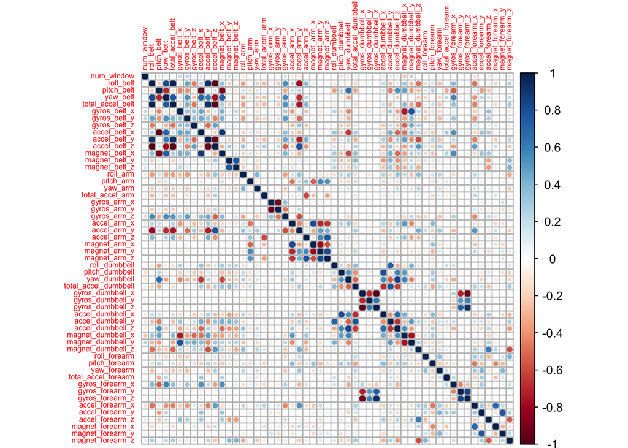

```r
corrplot(cor(trainData[, -length(names(trainData))]), method = "circle", tl.cex = 0.5)
```

#### 5.4. Partitioning trainData Dataset

trainData is partitioned into train and validation data in order to perform cross validation in upcoming steps.

```r
inTrain <- createDataPartition(trainData$classe, p = 0.7, list = FALSE)
trainn <- trainData[inTrain,]
validation <- trainData[-inTrain,]
```

## 6. Data Modeling

#### 6.1. Decision Tree

Using decision tree, we will fit a model for prediction purpose.

```r
modelDT <- rpart(classe~., data = trainn, method = "class")
predictDT <- predict(modelDT, validation, type = "class")
confusionMatrix(validation$classe, predictDT)$overall[1]*100
```

```
## Accuracy
## 83.38148
```

#### 6.2. Random Forest

We will try Random Forest algorithm because it automatically selects important variables and is robust to correlated covariates & outliers in general.

```r
modelRF <- randomForest(classe~., data = trainn)
predictRF <- predict(modelRF, validation)
confusionMatrix(validation$classe, predictRF)$overall[1]*100
```

```
## Accuracy
## 99.66015
```

## 7. Predicting Manner of Exercise for Test Data

Now, we will apply Random Forest model to the test data downloaded from the data source to predict the manner of exercise done by subject. Applying modelRF prediction model to fetch results.

```r
predict(modelRF, testData[, -length(names(testData))])
```

```
##  1  2  3  4  5  6  7  8  9 10 11 12 13 14 15 16 17 18 19 20
##  B  A  B  A  A  E  D  B  A  A  B  C  B  A  E  E  A  B  B  B
## Levels: A B C D E
```